# Week 7: Network Data I - Fundamentals and Static Visualisation

161.307 Reproducible Visualisation for Statistics

School of Mathematical and Computational Sciences, Massey University

7 Sep 2026

## The plan for this week

- Lecture 1: What is a network, and how do we describe it?
- Lecture 2: Visualising networks: layouts, alternatives, and uncertainty about network statistics
- Tutorials: build/plot a network, encode attributes, compare representations, and (bridge) resample a network’s degree distribution the way we resampled means in Week 6

This week gives us the **structural grammar** (nodes, edges, layouts) that Week 8 will set in motion: spread *on* a network, over space and time.

Primary reference: Kolaczyk & Csárdi (2014), *Statistical Analysis of Network Data with R*

# Lecture 1: What is a network, and how do we describe it?

## From single processes to interacting systems

- Weeks 5-6 processes described **one thing at a time**: a position over time, an arrival count, a case count per generation
- The branching process in Week 5 assumed every infectious case could reach *anyone*, an implicit, unstated, fully-mixed population
- Real spread (disease, information, financial contagion) moves along **specific connections**: you can only infect the people you actually contact
- A network makes that contact structure explicit, and therefore “visualisable”

## Nodes, edges, and network types

- **Node / vertex**: an entity (a person, a city, a gene)
- **Edge / link**: a relationship between two nodes (a contact, a flight route, a co-authorship, an activation/repression)
- **Undirected** (contact, friendship) vs **directed** (follows, cites, “infects”)
- **Unweighted** (edge present/absent) vs **weighted** (edge carries a strength: contact duration, flight frequency, transmission probability)
- **Simple graph** (at most one edge per pair) vs **multigraph** (repeated edges, e.g. multiple contacts on different days)

## Three equivalent representations

| Representation | Structure | Best for |
| --- | --- | --- |
| Edge list | Two columns: `from`, `to` (+ optional weight) | Storage, sparse networks, tidy data pipelines |
| Adjacency matrix | $n \times n$ matrix, entry = edge (binary or weight) | Linear algebra, dense networks, some layouts |
| Adjacency list | Each node’s list of neighbours | Fast neighbourhood lookups (e.g. simulating spread) |

All three carry the *same information*; the right one depends on what you’re about to do with it.

## From edge list to graph object

```r
data(highschool, package = "ggraph")
head(highschool)

g <- as_tbl_graph(highschool, directed = FALSE)
g
```

- `highschool`: reported friendships between pupils, recorded in 1957 and 1958 (Coleman 1964), an edge list with a `year` attribute
- `tidygraph` wraps `igraph` in a **tidy, two-table** structure: one tibble for nodes, one for edges. Same philosophy as `dplyr`

## From edge list to graph object

```
  from to year
1    1 14 1957
2    1 15 1957
3    1 21 1957
4    1 54 1957
5    1 55 1957
6    2 21 1957
```

```
# A tbl_graph: 70 nodes and 506 edges
#
# An undirected multigraph with 1 component
#
# Node Data: 70 × 0 (active)
#
# Edge Data: 506 × 3
   from    to  year
  <int> <int> <dbl>
1     1    13  1957
2     1    14  1957
3     1    20  1957
# ℹ 503 more rows
```

## Moving between representations

```r
# edge list -> adjacency matrix
adj <- igraph::as_adjacency_matrix(g, sparse = FALSE)
adj[1:6, 1:6]

# node/edge tibbles (the tidygraph "two tables" view)
g |> activate(nodes) |> as_tibble() |> head(3)
g |> activate(edges) |> as_tibble() |> head(3)
```

- `activate()` chooses which table subsequent `mutate()`/`filter()` verbs apply to. A network is genuinely **two tidy tables joined by an index**, not one row-per-observation table

## Degree: the simplest network statistic

- **Degree** of a node = number of edges attached to it (neighbours, for a simple undirected graph)
- Directed graphs: split into **in-degree** and **out-degree**
- Degree is a *local* property (about one node) that we usually study as a **distribution** (across all nodes)

```r
g2 <- g |>
  activate(nodes) |>
  mutate(degree = centrality_degree())

g2 |> activate(nodes) |> as_tibble() |>
  ggplot(aes(degree)) +
  geom_bar() +
  labs(title = "Degree distribution: highschool network",
       x = "Degree", y = "Number of pupils") +
  theme_minimal()
```

## Degree: the simplest network statistic

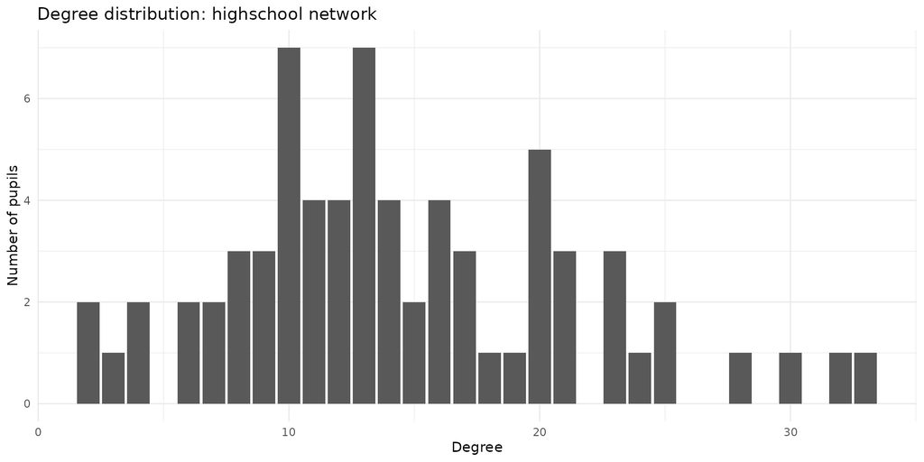

We already know how to read a distribution. Weeks 5-6 spent two weeks on exactly this. What’s new is *where the randomness comes from*

## Random graph models: a network is (often) a random process too

- Week 5’s central move was: write down a *generating process*, then simulate from it, before ever touching real data
- We can do the same for networks. The simplest possible model is called the **Erdős–Rényi random graph** $G(n, p)$:
  - $n$ nodes
  - **every possible pair** is connected independently with probability $p$. Literally $\binom{n}{2}$ independent coin flips
- This is Week 5’s “many independent Bernoulli/Poisson trials” idea, just applied to *pairs of nodes* instead of *time steps*

## Simulating an Erdős–Rényi graph

```r
set.seed(2026)
n <- 60
p <- 0.05

g_er <- play_erdos_renyi(n, p, directed = FALSE)

ggraph(g_er, layout = "fr") +
  geom_edge_link(alpha = 0.3) +
  geom_node_point(size = 1.8) +
  theme_void() +
  labs(title = paste0("Erdos-Renyi random graph, n = ", n, ", p = ", p))
```

- Reproducibility checkpoint, exactly as in Week 5: record `n`, `p`, the seed, and the layout algorithm. A random *graph* needs the same provenance as a random *walk*

## Simulating an Erdős–Rényi graph

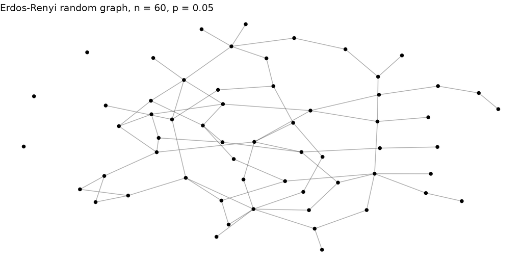

## The Poisson process strikes back

- In $G(n, p)$, each node’s degree is a **sum of $n-1$ independent Bernoulli($p$) trials**: $\text{degree} \sim \text{Binomial}(n-1, p)$
- For large $n$, small $p$, with $n p$ roughly constant, that binomial is well approximated by $\text{Poisson}(\lambda = (n-1)p)$
- This is a Poisson process building block (see Week 5), just reinterpreted: instead of “number of arrivals in a fixed time window”, it’s “number of edges attached to a fixed node”

```r
set.seed(2026)
n <- 300; p <- 0.02
g_er2 <- play_erdos_renyi(n, p, directed = FALSE) |>
  activate(nodes) |> mutate(degree = centrality_degree())

deg_df <- g_er2 |> activate(nodes) |> as_tibble()
lambda <- (n - 1) * p

ggplot(deg_df, aes(degree)) +
  geom_bar(aes(y = after_stat(prop)), fill = "steelblue", alpha = 0.6) +
  geom_point(data = data.frame(degree = 0:15,
                                prop = dpois(0:15, lambda)),
             aes(degree, prop), colour = "firebrick", size = 2) +
  labs(title = paste0("G(n,p) degree distribution vs Poisson(",
                       round(lambda, 1), ") overlay"),
       x = "Degree", y = "Proportion of nodes") +
  theme_minimal()
```

## The Poisson process strikes back

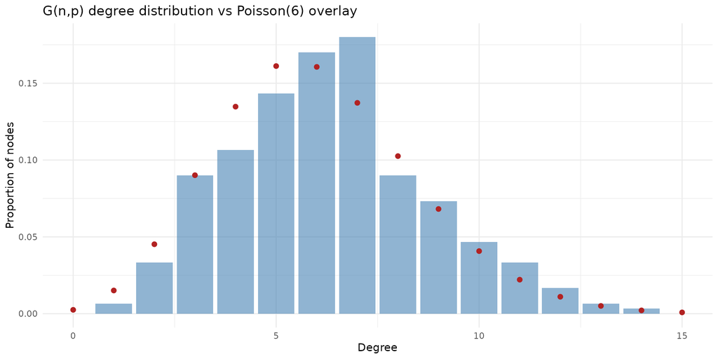

## Real networks are (usually) not Erdős–Rényi

- Real contact, social, and biological networks typically show:
  - **Clustering**: your friends tend to know each other (ER has almost none)
  - **Heavy-tailed degree**: a few hugely-connected hubs, most nodes with low degree (ER’s Poisson tail decays far too fast)
- Alternative generative models: **configuration model** (fix the degree sequence, wire edges at random), **preferential attachment** / Barabási–Albert (`play_barabasi_albert()`; “the rich get richer”), **small-world**
- Real life: airline networks, citation networks, and -critically for Week 8- **sexual-contact and superspreading networks** all show heavy tails. A handful of nodes carry disproportionate reach

## Small-world networks: clustered, yet close

- A third generative model, alongside configuration/preferential-attachment: the **Watts–Strogatz small-world model**
- Start from a **ring lattice**: each node connects only to its $k$ nearest neighbours: highly clustered, but the path between far-apart nodes is long (you have to walk around the ring)
- **Rewire** each edge with a small probability $\beta$ to a random node
- Even a *tiny* $\beta$ collapses the average path length dramatically, while clustering barely drops $\to$ this is the “small-world” effect behind “six degrees of separation”

## Simulating a small-world network

```r
set.seed(2026)
g_sw <- play_smallworld(n_dim = 1, dim_size = 60, order = 3, p = 0.02)

ggraph(g_sw, layout = "circle") +
  geom_edge_link(alpha = 0.25) +
  geom_node_point(size = 1.8) +
  theme_void() +
  labs(title = "Watts-Strogatz small-world graph (beta = 0.02)")
```

## Simulating a small-world network

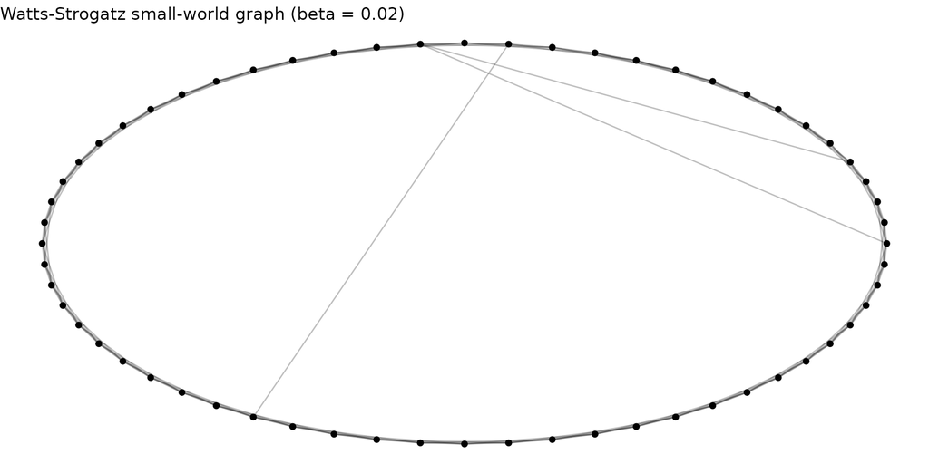

Most edges still look “local” (the ring survives); a handful of long chords are visible. Those are the rewired shortcuts.

## Why small-world matters for spreading processes

- Clustering stays close to the ring lattice’s value while average path length drops toward the (much lower) random-graph value: **local structure and global reach at the same time**
- Real social/contact networks are frequently small-world: tight local clusters (household, workplace) plus a few long-range ties (travel, weak ties)
- Epidemiological consequence: those few long-range edges are exactly what let an outbreak jump between otherwise-separate clusters, aka the “one super-spreading event links two cities” scenario
- Sets up Week 8 directly: the same network-constrained branching logic from Lecture 2, but now on a network with both dense local clustering *and* rare long-distance shortcuts

## Why the generating model matters for epidemics (preview)

- Week 5’s branching process assumed a fixed, unstructured $R_0$: every case infects $\text{Poisson}(R_0)$ new, *unspecified* susceptibles
- On a network, a case can only infect its **neighbours** $\to$ the degree distribution of the contact network directly shapes how an outbreak can grow
- A high-degree hub infected early can behave like a local super- spreading event, even with a *modest average* $R_0$. An unstructured branching model cannot represent this
- This is precisely the gap Week 8 fills: same branching logic, now **constrained by network structure**

## Beyond degree: summarising a whole network

| Statistic | Question it answers |
| --- | --- |
| Density | What fraction of possible edges exist? |
| Average degree | How many connections does a typical node have? |
| Clustering coefficient | Do a node’s neighbours know each other? |
| Path length / diameter | How many steps, typically, between two nodes? |
| Components | Is the network one connected piece, or several? |

## Beyond degree: summarising a whole network

```r
tibble::tibble(
  density    = igraph::edge_density(g2),
  n_nodes    = igraph::vcount(g2),
  n_edges    = igraph::ecount(g2),
  components = igraph::components(g2)$no
)
```

```
# A tibble: 1 × 4
  density n_nodes n_edges components
    <dbl>   <dbl>   <dbl>      <dbl>
1   0.210      70     506          1
```

## Lecture 1: summary

- A network is **two tidy tables** (nodes, edges) joined by an index; edge list, adjacency matrix, and adjacency list are equivalent views
- **Degree** is the local building block, studied for each node or as a distribution
- **Random graph models** (Erdős–Rényi and friends) are, structurally, a “write the generating process, then simulate” philosophy. Now generating *structure*, not a trajectory
- $G(n,p)$’s degree distribution is a **Poisson process in disguise**: same maths, new context
- Real networks are usually clustered, heavy-tailed and with surprisingly short paths, not Erdős–Rényi. *That* structural fact will matter enormously once we simulate spread on them in Week 8

## Looking ahead: Lecture 2

- *Drawing* a network: node-link diagrams and layout algorithms
- The “hairball” problem: overplotting’s structural cousin
- Alternatives: adjacency matrices, arc diagrams
- *Encoding attributes*: size, colour, width and the redundancy question from earlier weeks, replayed on nodes and edges
- A network statistic is a point estimate too (link to Week 6) What does a *confidence ribbon* look like for a node’s degree?

# Lecture 2: Visualising networks

## The default: node-link diagrams

```r
set.seed(1)
ggraph(g, layout = "fr") +
  geom_edge_link(alpha = 0.3) +
  geom_node_point(size = 2) +
  theme_void() +
  labs(title = "Highschool friendship network (force-directed)")
```

- Nodes as points, edges as lines $\to$ immediately readable
- But position carries **no inherent meaning**: it’s whatever the layout algorithm decided

## The default: node-link diagrams

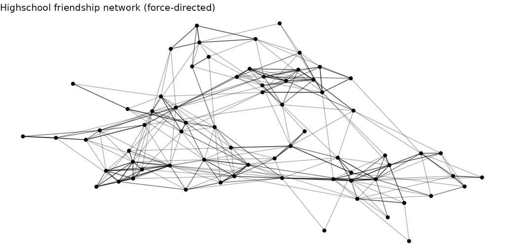

## Layout algorithms are a visual choice, not a fact

- **Force-directed** (`"fr"`, `"kk"`, `"stress"`): connected nodes attract, all nodes repel. It tends to surface clusters, but is **stochastic** and has no unique “correct” answer
- **Circular** (`"circle"`, `"linear"`): deterministic node order, good for showing *all* edges cleanly, bad for showing clusters
- **Grid / matrix-like** layouts: deterministic, but abstract
- Unlike Week 8’s spatial networks (where $x, y$ = real coordinates), today’s $x, y$ are **cosmetic**. Chosen to reduce edge crossings, nothing more
- Reproducibility checkpoint (`set.seed()`): a stochastic layout needs its seed recorded, or the figure cannot be regenerated identically

## Layout algorithms, compared

```r
library(patchwork)
set.seed(1)
p_fr    <- ggraph(g, layout = "fr") + geom_edge_link(alpha=.2) +
  geom_node_point(size=1.5) + theme_void() + labs(title = "Fruchterman-Reingold")
p_kk    <- ggraph(g, layout = "kk") + geom_edge_link(alpha=.2) +
  geom_node_point(size=1.5) + theme_void() + labs(title = "Kamada-Kawai")
p_circ  <- ggraph(g, layout = "circle") + geom_edge_link(alpha=.2) +
  geom_node_point(size=1.5) + theme_void() + labs(title = "Circle (deterministic)")

p_fr + p_kk + p_circ
```

## Layout algorithms, compared

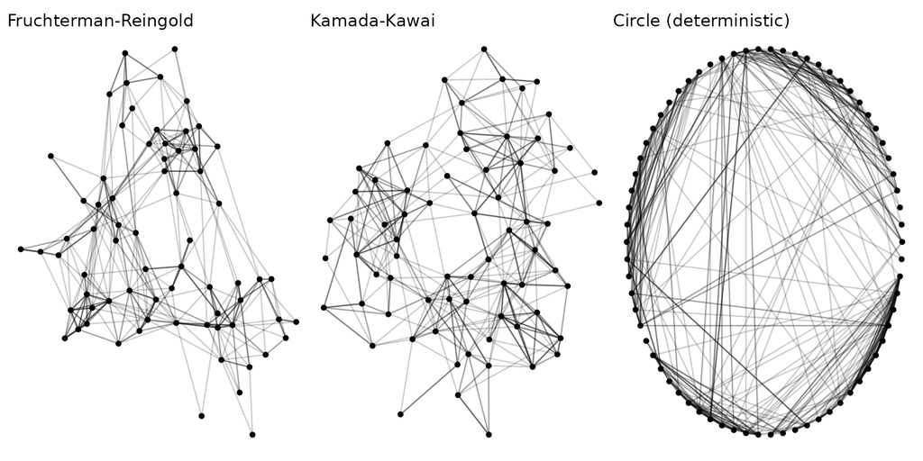

- Same data, three layouts, three different “stories” about structure

## The hairball problem: overplotting’s structural cousin

Week 5 showed a spaghetti plot degrade from readable to a smudge as $n$ grew. The same thing happens to node-link diagrams as **edges** accumulate.

```r
set.seed(2026)
g_dense <- play_erdos_renyi(150, p = 0.06, directed = FALSE)

ggraph(g_dense, layout = "fr") +
  geom_edge_link(alpha = 0.1) +
  geom_node_point(size = 1) +
  theme_void() +
  labs(title = "150 nodes, p = 0.06: the hairball")
```

## The hairball problem

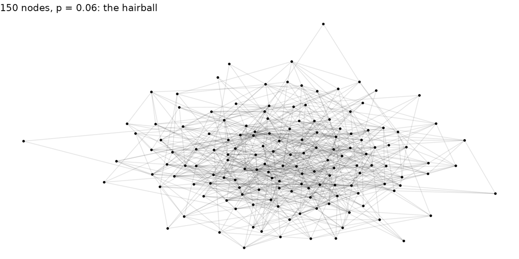

- Just like 2000 random-walk lines: individually meaningful edges, collectively an unreadable smudge
- Alpha-blending helps a little (as it did in Week 5) but does not fix the underlying representation problem

## Fixes: the network-diagram equivalents of Week 5’s toolkit

| Week 5 fix (trajectories) | Week 7 analogue (networks) |
| --- | --- |
| Reduce alpha | Reduce edge alpha / thin edges |
| Small multiples | Facet by community/time snapshot |
| Ribbon (summarise across draws) | Adjacency matrix / aggregate to block structure |
| Highlight a few + grey background | Highlight a subgraph on a greyed-out full network |

The overplotting *problem* is general; the *fix* has to match the data type. A ribbon has no equivalent for “this specific edge”. But an adjacency matrix does.

## Alternative 1: the adjacency matrix

```r
adj <- as.matrix(igraph::as_adjacency_matrix(g))
adj_df <- reshape2::melt(adj)

ggplot(adj_df, aes(Var1, Var2, fill = value)) +
  geom_tile() +
  scale_fill_gradient(low = "white", high = "steelblue") +
  coord_equal() + theme_minimal() +
  theme(axis.text = element_blank()) +
  labs(title = "Adjacency matrix view", x = NULL, y = NULL, fill = "Edge")
```

- No overplotting **by construction**: every possible edge gets exactly one cell, however dense the network
- Cost: individual paths/neighbourhoods are hard (impossible?) to trace by eye

## Alternative 1: the adjacency matrix

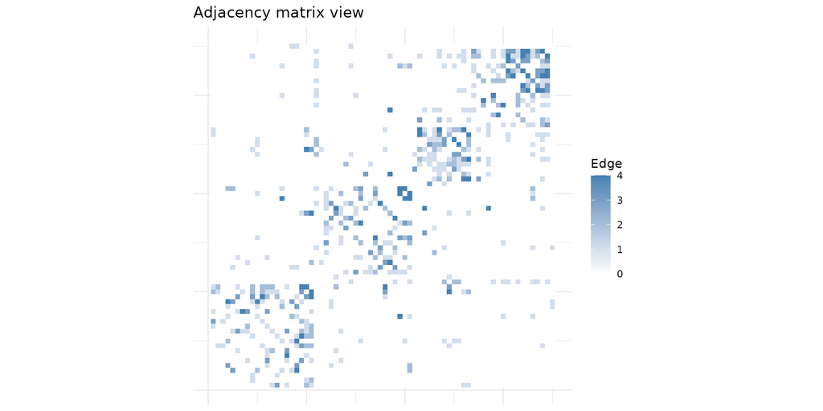

## Alternative 2: the arc diagram

```r
set.seed(1)
ggraph(g2, layout = "linear") +
  geom_edge_arc(alpha = 0.2) +
  geom_node_point(size = 2) +
  theme_void() +
  labs(title = "Arc diagram")
```

- Nodes on a single line, edges as arcs above $=$ a compromise between node-link (edges as edges) and matrix (deterministic node order)
- Like the matrix, its usefulness depends entirely on **node ordering**

## Alternative 2: the arc diagram

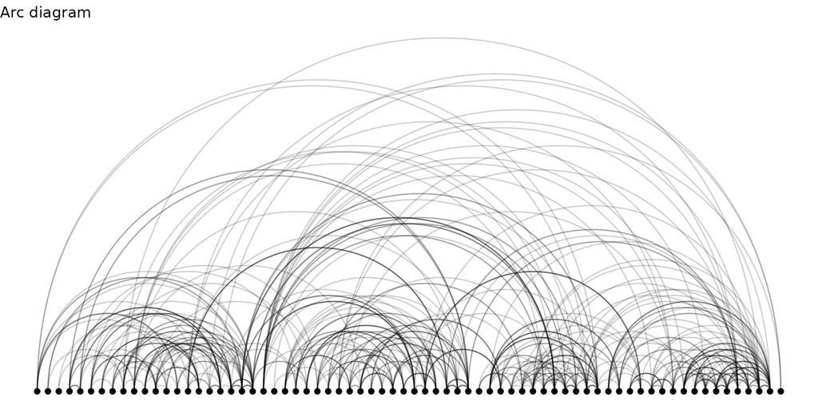

## Choosing a representation

| Representation | Shows density well? | Shows clusters well? | Scales to 1000s of edges? | Familiar to non-experts? |
| --- | --- | --- | --- | --- |
| Node-link | Poor at high density | Good (if layout works) | Poor (hairball) | Yes |
| Adjacency matrix | Excellent | Good *with reordering* | Excellent | No |
| Arc diagram | Moderate | Moderate *with ordering* | Moderate | Somewhat |

No universal winner. Same message as Week 6’s “no single correct interval encoding”: the right choice depends on the network, the question, and the audience.

## Encoding attributes: the redundancy question, again

```r
g3 <- g |>
  activate(nodes) |>
  mutate(degree = centrality_degree())

ggraph(g3, layout = "fr") +
  geom_edge_link(alpha = 0.2) +
  geom_node_point(aes(size = degree, colour = degree)) +
  scale_colour_viridis_c() +
  scale_size_area(max_size = 6) +
  theme_void() +
  labs(title = "Degree encoded as BOTH size and colour")
```

- Same variable mapped to two channels: helps for skimming, costs legend space, and can mislead if the two scales aren’t visually aligned
- Exactly the size-vs-colour redundancy question from earlier in the course, now on nodes instead of points in a scatterplot

## Encoding attributes: the redundancy question, again

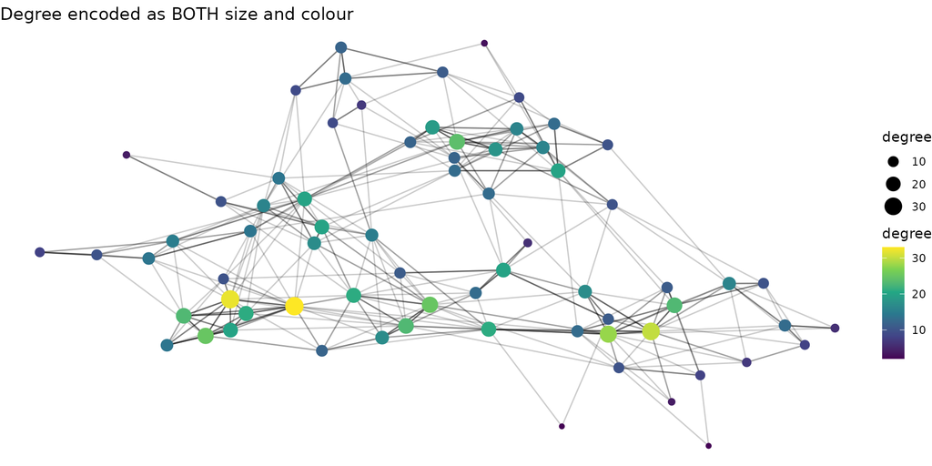

- We could encode two node attributes…

## Edge attributes: width, colour, alpha

- Edge weight (contact frequency, flight count, transmission probability) maps naturally to **width** or **alpha**
- Careful: `geom_edge_link()` width scales are easy to over-dramatise (a 10x weight difference should not look 10x as visually “loud”)
- Similar to the fan-chart lesson (Week 6): more channels of information cost visual weight, and past a point readers stop being able to decode them precisely

## Edge attributes in practice: weight → width

```r
edge_weights <- highschool |>
  count(from, to, name = "weight")

g_w <- as_tbl_graph(edge_weights, directed = FALSE)

set.seed(1)
ggraph(g_w, layout = "fr") +
  geom_edge_link(aes(width = weight), alpha = 0.4, colour = "steelblue") +
  scale_edge_width(range = c(0.3, 2.5)) +
  geom_node_point(size = 1.5) +
  theme_void() +
  labs(title = "Edge width = number of years a friendship was reported",
       edge_width = "Weight")
```

- `count(from, to)` collapses the 1957/1958 edge list into a single weighted edge per pair: repeated friendships (both years) get width 2
- `scale_edge_width(range = ...)` caps how extreme the width contrast gets, for exactly the reason on the previous slide: an uncapped scale makes a 2x weight difference looks dramatic

## Edge attributes in practice: weight → width

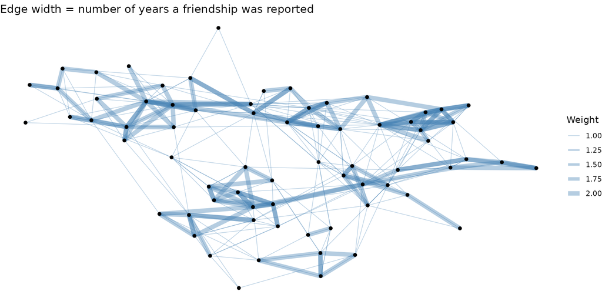

## Edge attributes in practice: category → colour

```r
g_year <- as_tbl_graph(highschool, directed = FALSE)

set.seed(1)
ggraph(g_year, layout = "fr") +
  geom_edge_link(aes(colour = factor(year)), alpha = 0.5) +
  geom_node_point(size = 1.5, colour = "grey30") +
  scale_edge_colour_manual(values = c("steelblue", "firebrick")) +
  theme_void() +
  labs(title = "Edge colour = survey year",
       edge_colour = "Year")
```

- **Categorical** edge attribute. Colour is the natural channel. Width would imply 1957 and 1958 are on an ordered scale (“more/less”)
- Match the channel to the *type* of the variable (not “looks good”)

## Edge attributes in practice: category → colour

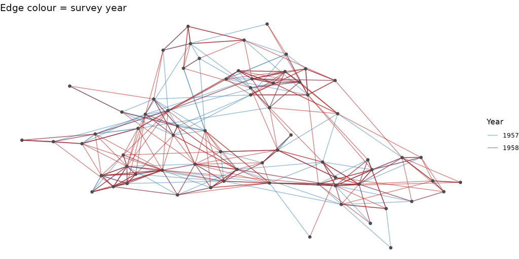

## Bootstrapping a network statistic

Resample nodes (with replacement) and recompute mean degree on the induced subgraph: the network analogue of Week 6’s bootstrap-the-mean

```r
set.seed(2026)
boot_mean_degree <- function(g) {
  nodes_tbl <- g |> activate(nodes) |> as_tibble()
  n <- nrow(nodes_tbl)
  resampled <- sample(seq_len(n), n, replace = TRUE)
  sub <- igraph::induced_subgraph(g, unique(resampled))
  mean(igraph::degree(sub))
}

boot_dist <- replicate(500, boot_mean_degree(g))

ggplot(data.frame(mean_degree = boot_dist), aes(mean_degree)) +
  geom_histogram(bins = 30, fill = "steelblue", alpha = 0.7) +
  labs(title = "Bootstrap distribution of mean degree (500 resamples)",
       x = "Mean degree", y = "Count") +
  theme_minimal()
```

## Bootstrapping a network statistic

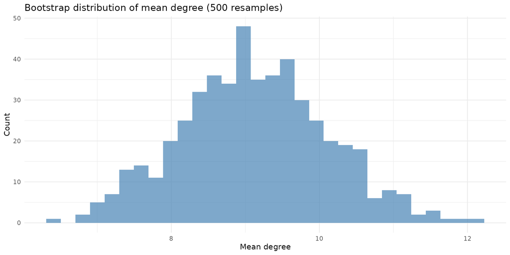

## Don’t dynamite-plot your network statistic

```r
library(patchwork)

summ <- data.frame(mean = mean(boot_dist), se = sd(boot_dist))

p_dynamite <- ggplot(summ, aes(x = "Highschool net", y = mean)) +
  geom_col(fill = "grey70", width = 0.4) +
  geom_errorbar(aes(ymin = mean - se, ymax = mean + se), width = 0.1) +
  labs(title = "Bad: bar + error bar", x = NULL, y = "Mean degree") +
  theme_minimal()

p_dots <- ggplot(data.frame(x = boot_dist), aes(x)) +
  ggdist::stat_dotsinterval(quantiles = 50, fill = "steelblue") +
  scale_y_continuous(NULL, breaks = NULL) +
  labs(title = "Better: quantile dotplot", x = "Mean degree") +
  theme_minimal()

p_dynamite + p_dots
```

- The bar hides the same thing it always hides: shape, skew, precision. Week 6’s critique applies to network statistics verbatim
- Which container is right depends on *why* the network is uncertain: sampling the population (Week 6-style sampling uncertainty) is a different claim from “many possible graphs under this random-graph model” (Week 5-style simulation variability) $\to$ Label which one you mean

## Don’t dynamite-plot your network statistic

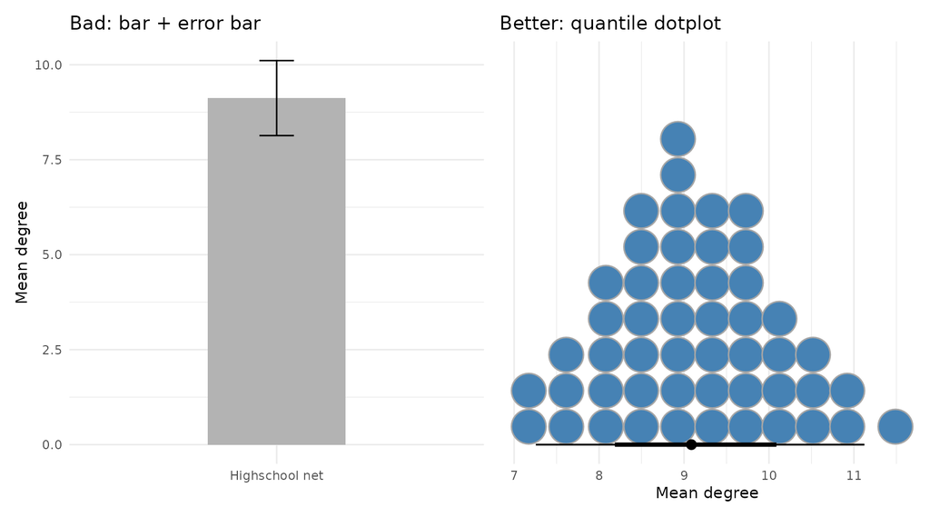

## Sneak peek: constraining Week 5’s branching process by structure

A Week-5-style branching process, where a case can only infect its **network neighbours**

```r
set.seed(2020) #setseed(2026) kills the epidemics!
n <- 60
g_contact <- play_erdos_renyi(n, p = 0.06, directed = FALSE)
adj <- as.matrix(igraph::as_adjacency_matrix(g_contact))

simulate_on_network <- function(adj, p_infect = 0.3, max_steps = 15) {
  n <- nrow(adj)
  infected <- rep(FALSE, n); infected[sample(n, 1)] <- TRUE
  new_cases <- sum(infected)
  for (t in 1:max_steps) {
    current <- which(infected)
    candidates <- which(!infected)
    would_infect <- sapply(candidates, function(j) {
      neighbours_infected <- sum(adj[j, current] == 1)
      runif(1) < 1 - (1 - p_infect)^neighbours_infected
    })
    newly <- candidates[would_infect]
    if (length(newly) == 0) break
    infected[newly] <- TRUE
    new_cases <- c(new_cases, length(newly))
  }
  new_cases
}

curve <- simulate_on_network(adj)

#and then plot!
```

## Sneak peek: constraining Week 5’s branching process by structure

1. We build a random contact network on 60 people (`play_erdos_renyi(n, p = 0.06)`) and pull out its adjacency matrix
2. We pick one random node as the seed case
3. At each time step, for every uninfected person `j`, we count how many of their network neighbours are currently infected (neighbours_infected), and infect `j` with probability $1 - (1 - p_{infect})^{neighbours_{infected}}$, i.e. each infected neighbour independently gets a $p_{infect} = 0.3$ chance to transmit. More infected neighbours means higher cumulative risk
4. Whoever gets infected becomes part of the “current” pool for the next step. The loop stops early if a step produces zero new infections
5. `new_cases` is the resulting step-by-step epidemic curve, which we then plot.

```r
ggplot(data.frame(step = seq_along(curve), new_cases = curve),
       aes(step, new_cases)) +
  geom_line() + geom_point() +
  labs(title = "New cases per step, spread constrained to network edges",
       subtitle = "Compare to Week 5's unconstrained branching process",
       x = "Step", y = "New cases") +
  theme_minimal()
```

## Sneak peek: constraining Week 5’s branching process by structure

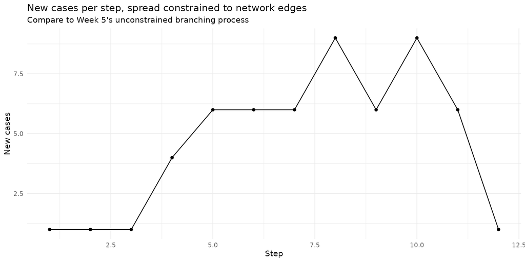

## Sneak peek: constraining Week 5’s branching process by structure

- Same “why simulate” logic as Week 5 (one run tells you little; run many, look at the ensemble), but the **ceiling on growth is now the network itself**, not just $R_0$
- Week 8 turns this into a full S/I/R process, animates it in time, and, because it’s still a stochastic simulation, wraps it in a Week 6-style ribbon across many runs

## Lecture 2: summary

- Node-link diagrams are the intuitive default, but degrade into a **hairball** exactly as spaghetti plots degrade under overplotting
- **Adjacency matrices** and **arc diagrams** trade intuitiveness for guaranteed scalability. Reordering nodes might be a key lever for both
- **Encoding attributes** on nodes/edges revisits the redundancy and visual-weight lessons from earlier in the course
- A network statistic is a **point estimate**: bootstrap it, and show the *distribution* (violin/dotplot), not a bar + error bar
- Constraining a Week 5 branching process to a Week 7 network is exactly the bridge Week 8 will build on

## Reading for this week

- Kolaczyk & Csárdi, *Statistical Analysis of Network Data with R*: chapters on network representation, summary statistics, and visualisation
- Wilke (2019): revisit Ch. 6-7 (distributions) and Ch. 16 (uncertainty) with networks in mind (same visual grammar, new data type)
- Handbook of Data Visualization: sections on graph/network drawing and graphical perception of connected data (II.4 and II.5; and IV.1 as an application)

## Looking ahead

- Tutorials this week: build and plot a network, encode attributes, compare node-link/matrix/arc, and bootstrap a network statistic into a Week-6-style container
- Week 8: networks gain **space** (real coordinates, basemaps) and **time** (snapshots, animation). They become the substrate on which we simulate actual epidemic spread, wrapped in the uncertainty containers from Week 6

161.307 - Reproducible Visualisation for Statistics